# lab6

Lucy Shao

March 8, 2017

### 1a

```r
gamblersRuin<-function(n1,n2,p){
  len<-0
  repeat {
  a<-rbinom(1,1,p)
  if(a==1){
    n1<-n1+1
    n2<-n2-1
  } else{
    n1<-n1-1
    n2<-n2+1
  }
  len<-len+1
   if (n1==0||n2==0) {
    break
  }
  }
  s<-c(len=len,n1=n1,n2=n2)
  return (s)
}
set.seed(2017)
gamblersRuin(n1 = 10, n2 = 10, p = 0.5)
```

```
## len  n1  n2
## 196   0  20
```

### 1b

Please write a for loop to simulate results from 10000 games using your gamblersRuin function with the formal arguments n1 = 5, n2 = 10 and p = 0.5. Store the result as one 10000 by 3 matrix res where each row is the output of each game and reveal the first 10 rows.

```r
res<-matrix(, nrow = 0, ncol = 3)
for(i in 1:10000){
   res<-rbind(res,gamblersRuin(n1 = 5, n2 = 10, p = 0.5))
}
head(res,n=10)
```

```
##       len n1 n2
##  [1,] 127  0 15
##  [2,]  15  0 15
##  [3,]  90 15  0
##  [4,]   9  0 15
##  [5,]  44 15  0
##  [6,]  27  0 15
##  [7,]  23  0 15
##  [8,]  61  0 15
##  [9,]  12 15  0
## [10,]   5  0 15
```

### 1c

```r
a<-table(res[,2])['0']
a/10000#the probability that the player one will go broke
```

```
##      0
## 0.6626
```

```r
mean(res[,1])#the expected number of tosses to determine the winner
```

```
## [1] 50.2648
```

### 1d

```r
res<-matrix(, nrow = 0, ncol = 3)
for(i in 1:10000){
   res<-rbind(res,gamblersRuin(n1 = 5, n2 = 10000, p = 0.49))
}
head(res,n=10)
```

```
##        len n1    n2
##  [1,] 1965  0 10005
##  [2,]   19  0 10005
##  [3,]   13  0 10005
##  [4,]    9  0 10005
##  [5,]   19  0 10005
##  [6,]   27  0 10005
##  [7,]   19  0 10005
##  [8,]   19  0 10005
##  [9,]  339  0 10005
## [10,]   11  0 10005
```

```r
a<-table(res[,2])['0']
a/10000#the probability that the player one will go broke
```

```
## 0
## 1
```

```r
mean(res[,1])#the expected number of tosses to determine the winner
```

```
## [1] 252.9076
```

### 2a

1. Complete the function colSumsFor.

```r
colSumsFor<- function(x){
v <- vector(length = ncol(x))
for (i in 1:ncol(x)) {
v[i]<-sum(x[,i])
}
names(v)<-colnames(x)
v
}
mat <- as.matrix(iris[, 1:4])
df <- iris[, 1:4]
colSumsFor(mat)
```

```
## Sepal.Length  Sepal.Width Petal.Length  Petal.Width
##        876.5        458.6        563.7        179.9
```

```r
#ii. Complete the function colSumsFor2.
colSumsFor2<-function(x) {
x <- as.matrix(x)
v <- vector(length = ncol(x))
for (i in 1:ncol(x)){
v[i]<-sum(x[ ,i])
}
names(v)<-colnames(x)
v
}
mat <- as.matrix(iris[, 1:4])
df <- iris[, 1:4]
colSumsFor2(mat)
```

```
## Sepal.Length  Sepal.Width Petal.Length  Petal.Width
##        876.5        458.6        563.7        179.9
```

```r
#iii. Complete the function colSumsApply.
colSumsApply <- function(x){
   apply(as.matrix(x), 2, sum)
}
colSumsApply(mat)
```

```
## Sepal.Length  Sepal.Width Petal.Length  Petal.Width
##        876.5        458.6        563.7        179.9
```

```r
#iv. Complete the function colSumsSapply.
colSumsSapply <- function(x)
{ sapply(as.data.frame(x),sum)
}
colSumsSapply(mat)
```

```
## Sepal.Length  Sepal.Width Petal.Length  Petal.Width
##        876.5        458.6        563.7        179.9
```

```r
#v. Complete the function colSumsLapply.
colSumsLapply <- function(x) {
do.call(cbind, lapply(as.data.frame(x),sum))
}
colSumsLapply(mat)
```

```
##      Sepal.Length Sepal.Width Petal.Length Petal.Width
## [1,]        876.5       458.6        563.7       179.9
```

```r
#vi. Issue the function colSumsCrossprod.
colSumsCrossprod <- function(x) {
    crossprod(rep(1, nrow(x)), as.matrix(x))[1, ]
}
colSumsCrossprod(mat)
```

```
## Sepal.Length  Sepal.Width Petal.Length  Petal.Width
##        876.5        458.6        563.7        179.9
```

### 2b

```r
df <- as.data.frame(matrix(rnorm(5000), 50, 100))
colSumsDf <- rbind(colSumsFor = system.time(replicate(n = 10000,colSumsFor(df))),colSumsFor2 = system.time(replicate(n = 10000, colSumsFor2(df))), colSumsApply = system.time(replicate(n = 10000, colSumsApply(df))), colSumsSapply = system.time(replicate(n = 10000, colSumsSapply(df))), colSumsLapply = system.time(replicate(n = 10000, colSumsLapply(df))), colSumsCrossprod = system.time(replicate(n = 10000, colSumsCrossprod(df))), colSums = system.time(replicate(n = 10000, colSums(df))))
colSumsDf
```

```
##                  user.self sys.self elapsed user.child sys.child
## colSumsFor          10.430    0.057  10.513          0         0
## colSumsFor2          7.011    0.218   7.248          0         0
## colSumsApply         7.104    0.203   7.325          0         0
## colSumsSapply        1.235    0.013   1.250          0         0
## colSumsLapply        0.958    0.009   0.970          0         0
## colSumsCrossprod     4.325    0.049   4.383          0         0
## colSums              4.316    0.027   4.351          0         0
```

```r
#  colSumsLapply is the fatest one
# colSumsFor is the slowest one
```

### 2c

```r
mat <- matrix(rnorm(5000), 50, 100)
colSumsMat <- rbind(colSumsFor = system.time(replicate(n = 10000, colSumsFor(mat))),
colSumsFor2 = system.time(replicate(n = 10000, colSumsFor2(mat))), colSumsApply = system.time(replicate(n = 10000, colSumsApply(mat))), colSumsSapply = system.time(replicate(n = 10000, colSumsSapply(mat))), colSumsLapply = system.time(replicate(n = 10000, colSumsLapply(mat))), colSumsCrossprod = system.time(replicate(n = 10000, colSumsCrossprod(mat))), colSums = system.time(replicate(n = 10000, colSums(mat))))
colSumsMat
```

```
##                  user.self sys.self elapsed user.child sys.child
## colSumsFor           2.208    0.112   2.328          0         0
## colSumsFor2          2.249    0.109   2.362          0         0
## colSumsApply         2.357    0.175   2.535          0         0
## colSumsSapply        3.748    0.141   3.896          0         0
## colSumsLapply        3.458    0.133   3.601          0         0
## colSumsCrossprod     0.118    0.005   0.122          0         0
## colSums              0.093    0.004   0.096          0         0
```

```r
# colSums is the fatest one
# colSumsSapply is the slowest one
```

### 3a

Please use the 50th to 150th observations in the iris dataset to answer the following questions. Fit the linear model Store your result to an object fit. Print summary(fit). Sepal.Length = Slope ∗ Petal.Length + Intercept. Reading from the summary, what is the Intercept and the Slope? What is the Multiple R-squared?

```r
data3<-iris[50:150,]
fit<-lm(data3$Sepal.Length~data3$Petal.Length)
summary(fit)
```

```
##
## Call:
## lm(formula = data3$Sepal.Length ~ data3$Petal.Length)
##
## Residuals:
##      Min       1Q   Median       3Q      Max
## -1.11985 -0.27762 -0.01985  0.28124  0.89758
##
## Coefficients:
##                    Estimate Std. Error t value Pr(>|t|)
## (Intercept)         3.23649    0.21308   15.19   <2e-16 ***
## data3$Petal.Length  0.61853    0.04303   14.37   <2e-16 ***
## ---
## Signif. codes:  0 '***' 0.001 '**' 0.01 '*' 0.05 '.' 0.1 ' ' 1
##
## Residual standard error: 0.384 on 99 degrees of freedom
## Multiple R-squared:  0.676,  Adjusted R-squared:  0.6728
## F-statistic: 206.6 on 1 and 99 DF,  p-value: < 2.2e-16
```

```r
#Intercept and the Slope? 3.23649 and  0.61853
#What is the Multiple R-squared? 0.676
```

### 3b

Extract the regression coefficients and store them to an object coefs. Draw a scatter plot for those two variables. Add a straight line to show the best linear fit.

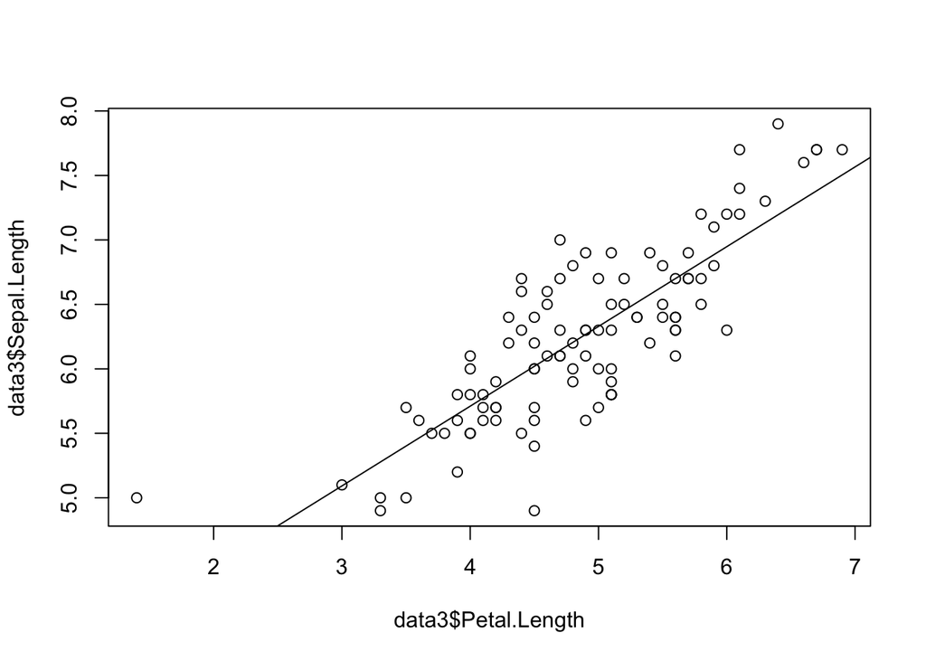

```r
coefs<-coefficients(fit)
plot(data3$Petal.Length,data3$Sepal.Length)
abline(coefs)
```

### 3c

Generates 4 diagnostics plots. Choose the number of points to be labelled as an potential outlier or a high leverage point by eyeballing from the plots. Specify id.n to be the number of points you want to label (set it as 0 if none).

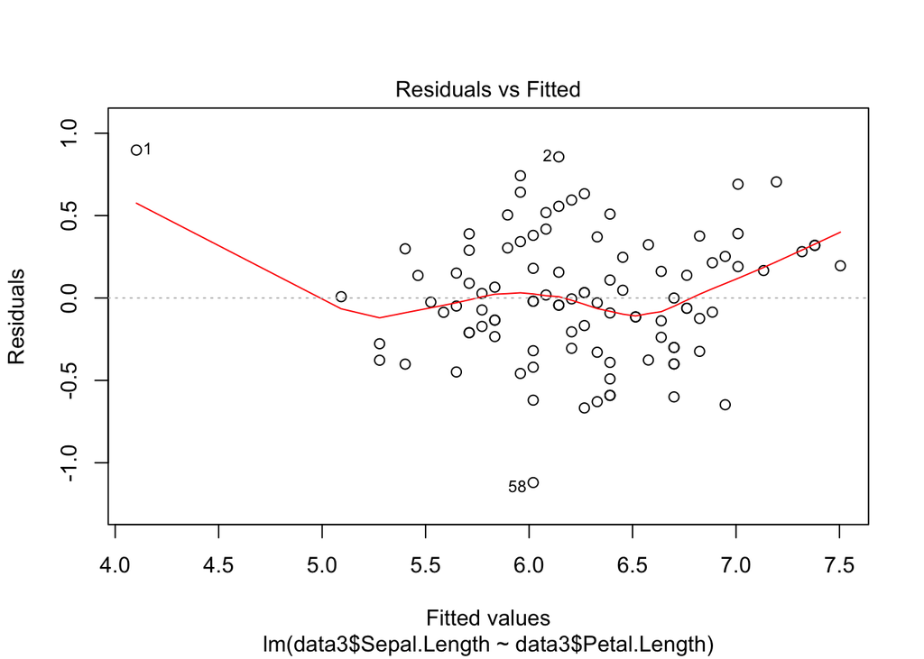

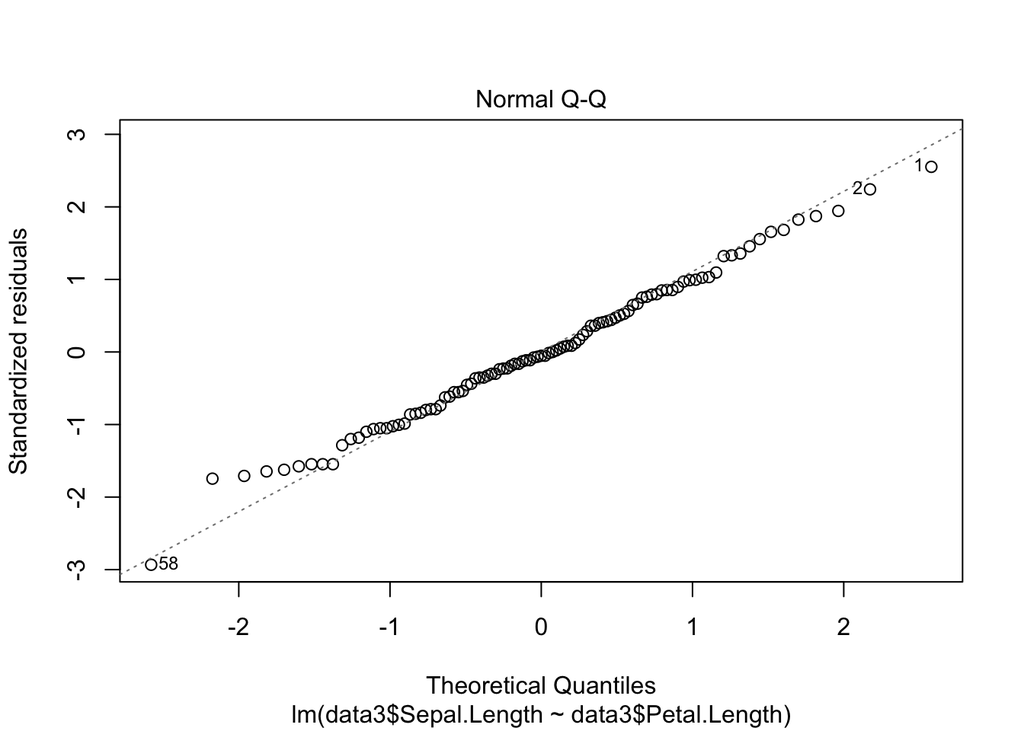

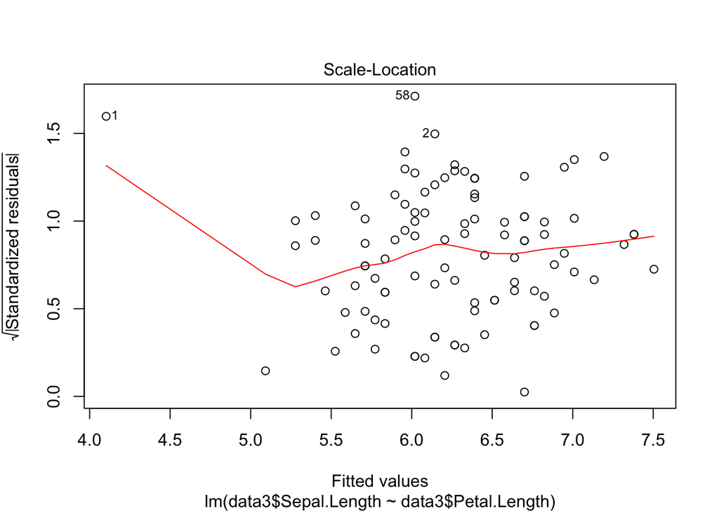

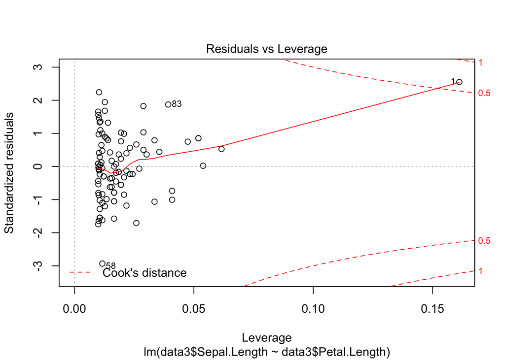

```r
plot(fit)
```

```r
id.n<-3
```

### 3d

Extract the fitted values and the residuals and store them as fitted and residual. Draw a scatter plot for residual(y)against fitted(x)

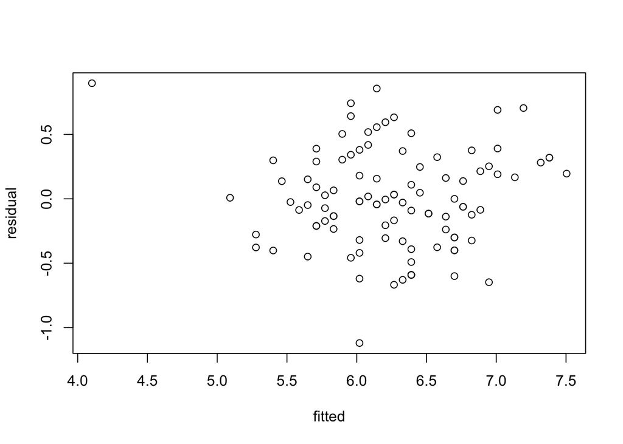

```r
fitted<-predict(fit)
residual<-residuals(fit)
plot(fitted, residual)
```

###3e. Evaluate 1 - (var(residual) / var(y), where y is the Sepal.Length of the 50th to 150th observations in the iris dataset.

```r
1-var(residual)/var(data3$Sepal.Length)
```

```
## [1] 0.6760398
```